# ERA plant growth and N uptake

# Physiological maturity

- Testing main effects of fertilizer and year of release
- Including primary experimental plots, i.e. no untreated seed plots and no density comparisons

## Grain

```r
m3 = lmer(Grain_kgdw_ha ~ R_Year.c*Fert + (1|Rep) + (1|Pos) + (1|Genotype) + (1|Pos:Fert) + (1|Rep:Row:Pos),  data = Data, na.action = na.exclude)
  anova(m3, ddf = "Kenward-Roger")
```

```
Analysis of Variance Table of type III  with  Kenward-Roger
approximation for degrees of freedom
                Sum Sq  Mean Sq NumDF  DenDF F.value    Pr(>F)
R_Year.c      17698793 17698793     1 10.015  22.947 0.0007312 ***
Fert          81046581 40523291     2 28.016  52.540 3.312e-10 ***
R_Year.c:Fert  4711361  2355680     2 91.927   3.054 0.0519733 .
---
Signif. codes:  0 ‘***’ 0.001 ‘**’ 0.01 ‘*’ 0.05 ‘.’ 0.1 ‘ ’ 1
```

```r
  summary(m3)
```

```
Linear mixed model fit by REML t-tests use Satterthwaite approximations to degrees of
  freedom [lmerMod]
Formula: Grain_kgdw_ha ~ R_Year.c * Fert + (1 | Rep) + (1 | Pos) + (1 |
    Genotype) + (1 | Pos:Fert) + (1 | Rep:Row:Pos)
   Data: Data

REML criterion at convergence: 2359

Scaled residuals:
     Min       1Q   Median       3Q      Max
-2.72132 -0.59794 -0.08286  0.48521  2.47038

Random effects:
 Groups      Name        Variance Std.Dev.
 Rep:Row:Pos (Intercept) 279034   528.2
 Pos:Fert    (Intercept)  19224   138.7
 Genotype    (Intercept) 279148   528.3
 Pos         (Intercept)      0     0.0
 Rep         (Intercept) 438907   662.5
 Residual                771288   878.2
Number of obs: 144, groups:
Rep:Row:Pos, 48; Pos:Fert, 12; Genotype, 12; Pos, 4; Rep, 4

Fixed effects:
                 Estimate Std. Error       df t value Pr(>|t|)
(Intercept)      1856.805    509.483   10.830   3.644  0.00396 **
R_Year.c           27.424      8.467   17.010   3.239  0.00482 **
Fert85           2277.225    337.818   34.220   6.741 9.25e-08 ***
Fert170          3473.848    337.818   34.220  10.283 5.27e-12 ***
R_Year.c:Fert85     7.720      7.181   75.140   1.075  0.28581
R_Year.c:Fert170   18.033      7.181   75.140   2.511  0.01418 *
---
Signif. codes:  0 ‘***’ 0.001 ‘**’ 0.01 ‘*’ 0.05 ‘.’ 0.1 ‘ ’ 1

Correlation of Fixed Effects:
            (Intr) R_Yr.c Fert85 Frt170 R_Y.:F8
R_Year.c    -0.620
Fert85      -0.332  0.337
Fert170     -0.332  0.337  0.500
R_Yr.c:Fr85  0.263 -0.424 -0.795 -0.397
R_Yr.c:F170  0.263 -0.424 -0.397 -0.795  0.500
```

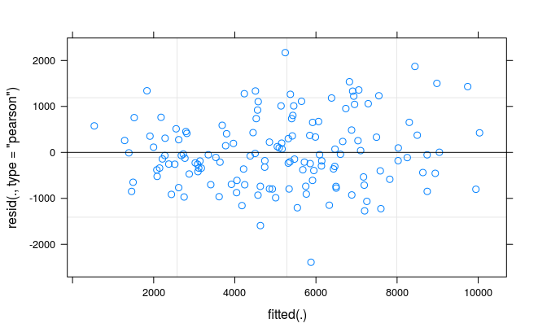

### Function for saving F tests

# save Ftests

## N uptake at physiological maturity

```
Analysis of Variance Table of type III  with  Kenward-Roger
approximation for degrees of freedom
               Sum Sq Mean Sq NumDF  DenDF F.value    Pr(>F)
R_Year.c       2182.4  2182.4     1  9.961   9.507   0.01163 *
Fert          28394.1 14197.1     2 30.838  61.846 1.614e-11 ***
R_Year.c:Fert   518.3   259.2     2 90.884   1.129   0.32786
---
Signif. codes:  0 ‘***’ 0.001 ‘**’ 0.01 ‘*’ 0.05 ‘.’ 0.1 ‘ ’ 1
```

- interaction of R_Year and fert was not significant

```r
lsmeans(m1, pairwise~Fert) %>%
        cld(Letters = c(letters))  %>%
        as.data.frame %>%
         filter(!is.na(lsmean))
```

```
NOTE: Results may be misleading due to involvement in interactions
```

| Fert | lsmean | SE | df | lower.CL | upper.CL | .group |
| --- | --- | --- | --- | --- | --- | --- |
| 0 | 47.05928 | 4.462205 | 6.913088 | 36.48089 | 57.63767 | a |
| 85 | 77.30148 | 4.475853 | 6.996787 | 66.69074 | 87.91223 | b |
| 170 | 115.90835 | 4.462205 | 6.913088 | 105.32996 | 126.48674 | c |

## Plots

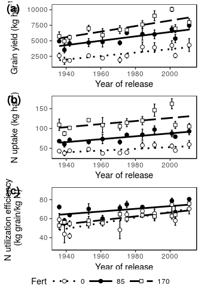

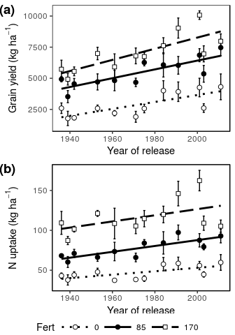

- Interpretation: Yield has increased with year of release with a slight interaction between fertilizer and year of release whereby the improvement due to breeding is increased under fertilized conditions. These yield improvements are supported by improved N uptake at all three fertilization levels (no interaction) and increased effeciency with which plant N is convrted to harvestable yield (kg grain yield / per unit plant N).
- Trends mirror those found in literature except that the increased N uptake at 0N contrasts earlier work where no improved N uptake was observed in low N soils (Haegle 2013, Woli 2016). Yet even just considering 0N plots there is a significant relationship with year of release (F(1,9.9) = 7.05, p = 0.02). This may be due to either increased time span evaluated here or stress conditions.

```r
sub = Data %>% filter(Fert == "0")
m2 = lmer(Final_kgN_ha ~ R_Year.c + (1|Rep) + (1|Pos) + (1|Genotype),  data = sub, na.action = na.exclude)
  anova(m2, ddf = "Kenward-Roger")
```

```
Analysis of Variance Table of type III  with  Kenward-Roger
approximation for degrees of freedom
         Sum Sq Mean Sq NumDF  DenDF F.value  Pr(>F)
R_Year.c 704.88  704.88     1 9.9942  7.0556 0.02407 *
---
Signif. codes:  0 ‘***’ 0.001 ‘**’ 0.01 ‘*’ 0.05 ‘.’ 0.1 ‘ ’ 1
```

```r
  summary(m2)
```

```
Linear mixed model fit by REML t-tests use Satterthwaite approximations to degrees of
  freedom [lmerMod]
Formula: Final_kgN_ha ~ R_Year.c + (1 | Rep) + (1 | Pos) + (1 | Genotype)
   Data: sub

REML criterion at convergence: 367.1

Scaled residuals:
    Min      1Q  Median      3Q     Max
-1.2755 -0.5998 -0.1855  0.3578  2.5088

Random effects:
 Groups   Name        Variance Std.Dev.
 Genotype (Intercept) 22.18    4.709
 Pos      (Intercept)  0.00    0.000
 Rep      (Intercept) 26.15    5.114
 Residual             99.90    9.995
Number of obs: 48, groups:  Genotype, 12; Pos, 4; Rep, 4

Fixed effects:
            Estimate Std. Error       df t value Pr(>|t|)
(Intercept) 39.00786    4.36699  8.95800   8.932 9.37e-06 ***
R_Year.c     0.21569    0.07874 10.00000   2.739   0.0209 *
---
Signif. codes:  0 ‘***’ 0.001 ‘**’ 0.01 ‘*’ 0.05 ‘.’ 0.1 ‘ ’ 1

Correlation of Fixed Effects:
         (Intr)
R_Year.c -0.672
```

```r
  confint(m2)
```

```
Computing profile confidence intervals ...
```

```
                  2.5 %     97.5 %
.sig01       0.00000000  9.0018495
.sig02       0.00000000  6.1484113
.sig03       0.00000000 12.4380605
.sigma       7.97709305 13.0860580
(Intercept) 30.49327924 47.5282964
R_Year.c     0.05824667  0.3728236
```

# Nitrogen use efficiency metrics for supplemental

## Nitrogen utilization efficiency

```r
m2 = lmer(NUtE ~ R_Year.c*Fert + (1|Rep) + (1|Pos) + (1|Genotype) + (1|Pos:Fert) + (1|Rep:Row:Pos),  data = Data, na.action = na.exclude)
  anova(m2, ddf = "Kenward-Roger")
```

```
Analysis of Variance Table of type III  with  Kenward-Roger
approximation for degrees of freedom
               Sum Sq Mean Sq NumDF  DenDF F.value   Pr(>F)
R_Year.c      1273.39 1273.39     1  9.953 19.7973 0.001251 **
Fert          1965.12  982.56     2 30.935 15.2758 2.43e-05 ***
R_Year.c:Fert  354.36  177.18     2 90.942  2.7546 0.068952 .
---
Signif. codes:  0 ‘***’ 0.001 ‘**’ 0.01 ‘*’ 0.05 ‘.’ 0.1 ‘ ’ 1
```

- N utilization efficiency was highest at 85kgN, yet the slope for R_Year is greatest at 0N, followed by 170N

## Grain metrics

```r
m1 = lmer(Grain_kgN_ha ~ R_Year.c*Fert + (1|Rep) + (1|Pos) + (1|Pos:Fert)  + (1|Genotype) + (1|Rep:Row:Pos),  data = Data, na.action = na.exclude)
  anova(m1, ddf = "Kenward-Roger")
```

```
Analysis of Variance Table of type III  with  Kenward-Roger
approximation for degrees of freedom
               Sum Sq Mean Sq NumDF  DenDF F.value    Pr(>F)
R_Year.c       1246.3  1246.3     1  9.960   9.110   0.01299 *
Fert          19078.2  9539.1     2 30.833  69.728 3.617e-12 ***
R_Year.c:Fert   158.3    79.2     2 90.881   0.579   0.56271
---
Signif. codes:  0 ‘***’ 0.001 ‘**’ 0.01 ‘*’ 0.05 ‘.’ 0.1 ‘ ’ 1
```

```r
  summary(m1)
```

```
Linear mixed model fit by REML t-tests use Satterthwaite approximations to degrees of
  freedom [lmerMod]
Formula: Grain_kgN_ha ~ R_Year.c * Fert + (1 | Rep) + (1 | Pos) + (1 |
    Pos:Fert) + (1 | Genotype) + (1 | Rep:Row:Pos)
   Data: Data

REML criterion at convergence: 1143.3

Scaled residuals:
    Min      1Q  Median      3Q     Max
-2.7215 -0.5580 -0.0537  0.4401  3.2710

Random effects:
 Groups      Name        Variance Std.Dev.
 Rep:Row:Pos (Intercept)  28.39    5.328
 Genotype    (Intercept)  28.75    5.362
 Pos:Fert    (Intercept)   0.00    0.000
 Pos         (Intercept)   0.00    0.000
 Rep         (Intercept)  50.89    7.134
 Residual                136.80   11.696
Number of obs: 143, groups:
Rep:Row:Pos, 48; Genotype, 12; Pos:Fert, 12; Pos, 4; Rep, 4

Fixed effects:
                 Estimate Std. Error       df t value Pr(>|t|)
(Intercept)      22.71617    5.59838 11.68000   4.058  0.00167 **
R_Year.c          0.19321    0.09598 21.43000   2.013  0.05685 .
Fert85           23.87395    4.28763 90.04000   5.568 2.64e-07 ***
Fert170          51.57683    4.26399 89.63000  12.096  < 2e-16 ***
R_Year.c:Fert85   0.04734    0.09496 89.72000   0.498  0.61937
R_Year.c:Fert170  0.10448    0.09484 89.63000   1.102  0.27359
---
Signif. codes:  0 ‘***’ 0.001 ‘**’ 0.01 ‘*’ 0.05 ‘.’ 0.1 ‘ ’ 1

Correlation of Fixed Effects:
            (Intr) R_Yr.c Fert85 Frt170 R_Y.:F8
R_Year.c    -0.639
Fert85      -0.379  0.407
Fert170     -0.381  0.409  0.497
R_Yr.c:Fr85  0.315 -0.493 -0.828 -0.414
R_Yr.c:F170  0.316 -0.494 -0.412 -0.829  0.499
```

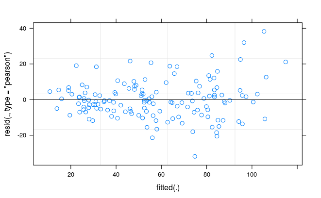

```r
  plot(m1)
```

```r
  DF = GetFstat(m1)
  DFsup = left_join(DFsup, DF)
 m2 = lmer(Grain_FracN.leco ~ R_Year.c*Fert + (1|Rep) + (1|Pos)  + (1|Pos:Fert)  + (1|Genotype) + (1|Rep:Row:Pos),  data = Data, na.action = na.exclude)
  anova(m2, ddf = "Kenward-Roger")
```

```
Analysis of Variance Table of type III  with  Kenward-Roger
approximation for degrees of freedom
                  Sum Sq    Mean Sq NumDF  DenDF F.value    Pr(>F)
R_Year.c      3.1070e-05 3.1070e-05     1 10.051 27.6205 0.0003643 ***
Fert          3.3783e-05 1.6891e-05     2 27.741 15.0163 3.809e-05 ***
R_Year.c:Fert 2.0280e-06 1.0138e-06     2 91.121  0.9012 0.4096577
---
Signif. codes:  0 ‘***’ 0.001 ‘**’ 0.01 ‘*’ 0.05 ‘.’ 0.1 ‘ ’ 1
```

```r
  summary(m2)
```

```
Linear mixed model fit by REML t-tests use Satterthwaite approximations to degrees of
  freedom [lmerMod]
Formula: Grain_FracN.leco ~ R_Year.c * Fert + (1 | Rep) + (1 | Pos) +
    (1 | Pos:Fert) + (1 | Genotype) + (1 | Rep:Row:Pos)
   Data: Data

REML criterion at convergence: -1414.9

Scaled residuals:
    Min      1Q  Median      3Q     Max
-1.9876 -0.5660 -0.0648  0.4467  4.2561

Random effects:
 Groups      Name        Variance  Std.Dev.
 Rep:Row:Pos (Intercept) 1.973e-07 0.0004442
 Genotype    (Intercept) 1.763e-07 0.0004198
 Pos:Fert    (Intercept) 2.406e-08 0.0001551
 Pos         (Intercept) 3.386e-08 0.0001840
 Rep         (Intercept) 0.000e+00 0.0000000
 Residual                1.125e-06 0.0010606
Number of obs: 143, groups:
Rep:Row:Pos, 48; Genotype, 12; Pos:Fert, 12; Pos, 4; Rep, 4

Fixed effects:
                   Estimate Std. Error         df t value Pr(>|t|)
(Intercept)       1.225e-02  3.895e-04  2.421e+01  31.445  < 2e-16 ***
R_Year.c         -3.827e-05  8.228e-06  2.113e+01  -4.652 0.000135 ***
Fert85           -7.505e-04  4.076e-04  2.538e+01  -1.841 0.077284 .
Fert170           1.488e-03  4.051e-04  2.591e+01   3.674 0.001092 **
R_Year.c:Fert85   1.027e-05  8.678e-06  9.243e+01   1.184 0.239449
R_Year.c:Fert170 -7.031e-08  8.664e-06  9.227e+01  -0.008 0.993543
---
Signif. codes:  0 ‘***’ 0.001 ‘**’ 0.01 ‘*’ 0.05 ‘.’ 0.1 ‘ ’ 1

Correlation of Fixed Effects:
            (Intr) R_Yr.c Fert85 Frt170 R_Y.:F8
R_Year.c    -0.790
Fert85      -0.516  0.418
Fert170     -0.520  0.421  0.497
R_Yr.c:Fr85  0.415 -0.526 -0.799 -0.399
R_Yr.c:F170  0.416 -0.527 -0.397 -0.799  0.499
```

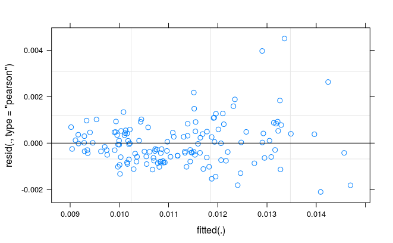

```r
  plot(m2)
```

```r
  DF = GetFstat(m2)
  DFsup = left_join(DFsup, DF)
```

- No interaction between Year of release and fertilizer in grain %N or total grain N, removed from model. N export in grain increased at .24kg/ha/yr. Meanwhile percent N in grain decreased approximately 0.25% over this period.

## Stover and harvest index

```r
# m1 = lmer(Stover_kgdw_ha ~ R_Year.c*Fert + (1|Rep) + (1|Pos) + (1|Pos:Fert)  + (1|Genotype) + (1|Rep:Row:Pos),  data = Data, na.action = na.exclude)
#   anova(m1, ddf = "Kenward-Roger")
#   #summary(m1)
#   plot(m1)
m1 = lmer(Stover_kgN_ha ~ R_Year.c*Fert + (1|Rep) + (1|Pos) + (1|Pos:Fert)  + (1|Genotype) + (1|Rep:Row:Pos),  data = Data, na.action = na.exclude)
  anova(m1, ddf = "Kenward-Roger")
```

```
Analysis of Variance Table of type III  with  Kenward-Roger
approximation for degrees of freedom
              Sum Sq Mean Sq NumDF  DenDF F.value    Pr(>F)
R_Year.c       54.41   54.41     1  9.999  2.0891   0.17895
Fert          671.56  335.78     2 31.890 12.8916 7.889e-05 ***
R_Year.c:Fert 155.09   77.55     2 91.867  2.9772   0.05587 .
---
Signif. codes:  0 ‘***’ 0.001 ‘**’ 0.01 ‘*’ 0.05 ‘.’ 0.1 ‘ ’ 1
```

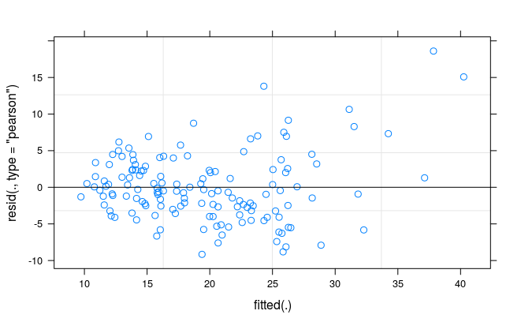

```r
  #summary(m1)
  plot(m1)
```

```r
  DF = GetFstat(m1)
  DFsup = left_join(DFsup, DF)
 m2 = lmer(Stover_FracN.leco ~ R_Year.c*Fert + (1|Rep) + (1|Pos) + (1|Pos:Fert)  + (1|Genotype) + (1|Rep:Row:Pos),  data = Data, na.action = na.exclude)
  anova(m2, ddf = "Kenward-Roger")
```

```
Analysis of Variance Table of type III  with  Kenward-Roger
approximation for degrees of freedom
                  Sum Sq    Mean Sq NumDF  DenDF F.value   Pr(>F)
R_Year.c      3.6000e-08 3.6000e-08     1 10.065  0.0848 0.776838
Fert          7.0531e-06 3.5266e-06     2 31.890  8.2987 0.001254 **
R_Year.c:Fert 1.5297e-06 7.6480e-07     2 91.867  1.7998 0.171110
---
Signif. codes:  0 ‘***’ 0.001 ‘**’ 0.01 ‘*’ 0.05 ‘.’ 0.1 ‘ ’ 1
```

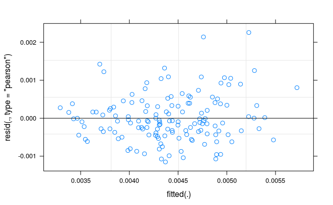

```r
  #summary(m2)
  plot(m2)
```

```r
  DF = GetFstat(m2)
  DFsup = left_join(DFsup, DF)
```

Total Stover N increases with year of releaes in 85kgN plots, and somewhat though highly variable in 170kg N plots. However, it is relatively flat at 0kg N, indicating fairly complete remobilization

## Harvest index and N partitioning

```r
tmp = Data %>% mutate(HarvestIndexBiomass = Grain_kgdw_ha/Total_kgdw_ha)
m1 = lmer(HarvestIndexBiomass ~ R_Year.c*Fert + (1|Rep) + (1|Pos) + (1|Pos:Fert)   + (1|Genotype) + (1|Rep:Row:Pos),  data = tmp, na.action = na.exclude)
  anova(m1, ddf = "Kenward-Roger")
```

```
Analysis of Variance Table of type III  with  Kenward-Roger
approximation for degrees of freedom
                Sum Sq  Mean Sq NumDF  DenDF F.value    Pr(>F)
R_Year.c      0.021206 0.021206     1  9.998   9.295   0.01228 *
Fert          0.165614 0.082807     2 31.890  36.297 6.054e-09 ***
R_Year.c:Fert 0.018152 0.009076     2 91.867   3.978   0.02203 *
---
Signif. codes:  0 ‘***’ 0.001 ‘**’ 0.01 ‘*’ 0.05 ‘.’ 0.1 ‘ ’ 1
```

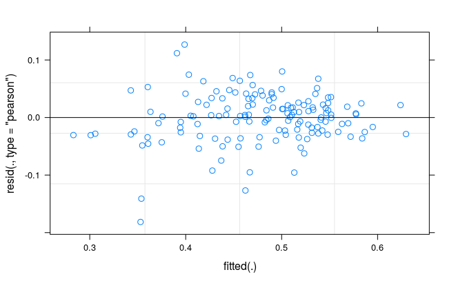

```r
  #summary(m1)
  plot(m1)
```

```r
  DF = GetFstat(m1)
  DFsup = left_join(DFsup, DF)
tmp = Data %>% mutate(HarvestIndexN = Grain_kgN_ha/Final_kgN_ha)
m1 = lmer(HarvestIndexN ~ R_Year.c*Fert + (1|Rep)  + (1|Pos) + (1|Pos:Fert)   + (1|Genotype) + (1|Rep:Row:Pos),  data = tmp, na.action = na.exclude)
  anova(m1, ddf = "Kenward-Roger")
```

```
Analysis of Variance Table of type III  with  Kenward-Roger
approximation for degrees of freedom
                Sum Sq  Mean Sq NumDF  DenDF F.value    Pr(>F)
R_Year.c      0.001577 0.001577     1  9.990  0.4155  0.533719
Fert          0.234881 0.117441     2 30.902 30.9341 4.201e-08 ***
R_Year.c:Fert 0.036873 0.018437     2 90.922  4.8562  0.009912 **
---
Signif. codes:  0 ‘***’ 0.001 ‘**’ 0.01 ‘*’ 0.05 ‘.’ 0.1 ‘ ’ 1
```

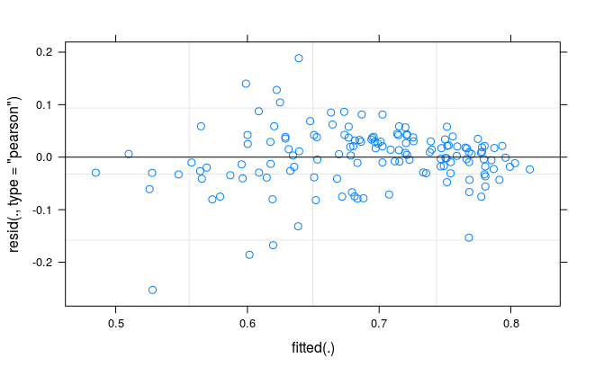

```r
  #summary(m1)
  plot(m1)
```

```r
   DF = GetFstat(m1)
  DFsup = left_join(DFsup, DF)
```

*Significant interactions between both terms and year of release. Harvest index increases with year of release at low and high N, slightly lower increase at middle N partitioning to grain increases at 0N, but has been level or slight decrease at 85 and 170N.

# Sequential harvests

## V6 biomass and N uptake

```r
m1 = lmer( log(T1_kgdw_ha)~ R_Year.c*Fert + (1|Rep) + (1|Pos) + (1|Pos:Fert) + (1|Genotype) + (1|Rep:Row:Pos),  data = Data, na.action = na.exclude)
  anova(m1, ddf = "Kenward-Roger")
```

```
Analysis of Variance Table of type III  with  Kenward-Roger
approximation for degrees of freedom
                Sum Sq  Mean Sq NumDF  DenDF F.value Pr(>F)
R_Year.c      0.088150 0.088150     1 10.129 1.17639 0.3032
Fert          0.213940 0.106970     2 10.725 1.42754 0.2820
R_Year.c:Fert 0.016542 0.008271     2 86.940 0.11038 0.8956
```

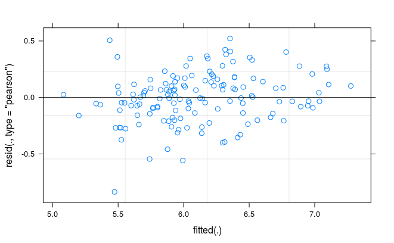

```r
  plot(m1) %>% print
```

```r
  DF = GetFstat(m1)
  DFsup = left_join(DFsup, DF)
m2 = lmer(log(T1_kgN_ha)~ R_Year.c*Fert + (1|Rep) + (1|Pos) + (1|Pos:Fert) + (1|Genotype) + (1|Rep:Row:Pos),  data = Data, na.action = na.exclude)
  anova(m2, ddf = "Kenward-Roger")
```

```
Analysis of Variance Table of type III  with  Kenward-Roger
approximation for degrees of freedom
               Sum Sq  Mean Sq NumDF  DenDF F.value  Pr(>F)
R_Year.c      0.18581 0.185812     1 10.199 2.46434 0.14693
Fert          0.47483 0.237415     2  9.335 3.14872 0.09014 .
R_Year.c:Fert 0.03145 0.015727     2 85.536 0.20858 0.81215
---
Signif. codes:  0 ‘***’ 0.001 ‘**’ 0.01 ‘*’ 0.05 ‘.’ 0.1 ‘ ’ 1
```

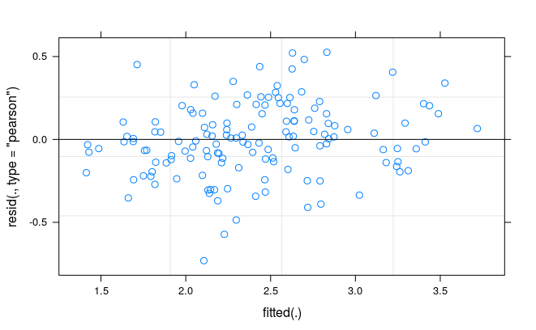

```r
  plot(m2) %>% print
```

```r
  DF = GetFstat(m2)
  DFsup = left_join(DFsup, DF)
```

- For biomass and N uptake at V6 there was no ineraction between year of release and fertilizer, removed from models. Both variables needed to be log transformed

## R1 biomass and N uptake

```r
m1 = lmer(T2_kgdw_ha~ R_Year.c*Fert + (1|Rep)+ (1|Pos) + (1|Pos:Fert) + (1|Genotype) + (1|Rep:Row:Pos),  data = Data, na.action = na.exclude)
  anova(m1, ddf = "Kenward-Roger")
```

```
Analysis of Variance Table of type III  with  Kenward-Roger
approximation for degrees of freedom
                Sum Sq  Mean Sq NumDF  DenDF F.value    Pr(>F)
R_Year.c       5022713  5022713     1 10.121  4.7743 0.0534728 .
Fert          24194476 12097238     2 15.335 11.4990 0.0008895 ***
R_Year.c:Fert   230678   115339     2 89.422  0.1096 0.8962814
---
Signif. codes:  0 ‘***’ 0.001 ‘**’ 0.01 ‘*’ 0.05 ‘.’ 0.1 ‘ ’ 1
```

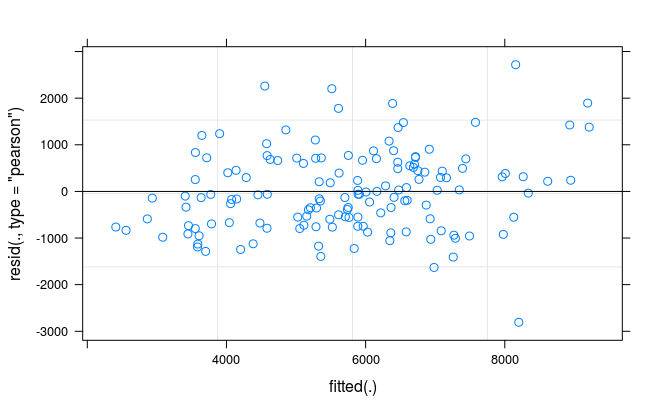

```r
  plot(m1) %>% print
```

```r
  DF = GetFstat(m1)
  DFmain = left_join(DFmain, DF)
m2 = lmer(T2_kgN_ha~ R_Year.c*Fert + (1|Rep) + (1|Pos) + (1|Pos:Fert) + (1|Genotype) + (1|Rep:Row:Pos),  data = Data, na.action = na.exclude)
  anova(m2, ddf = "Kenward-Roger")
```

```
Analysis of Variance Table of type III  with  Kenward-Roger
approximation for degrees of freedom
               Sum Sq Mean Sq NumDF  DenDF F.value    Pr(>F)
R_Year.c        870.7   870.7     1  9.984   3.377   0.09601 .
Fert          20387.4 10193.7     2 31.890  39.539 2.318e-09 ***
R_Year.c:Fert   579.5   289.8     2 91.867   1.124   0.32942
---
Signif. codes:  0 ‘***’ 0.001 ‘**’ 0.01 ‘*’ 0.05 ‘.’ 0.1 ‘ ’ 1
```

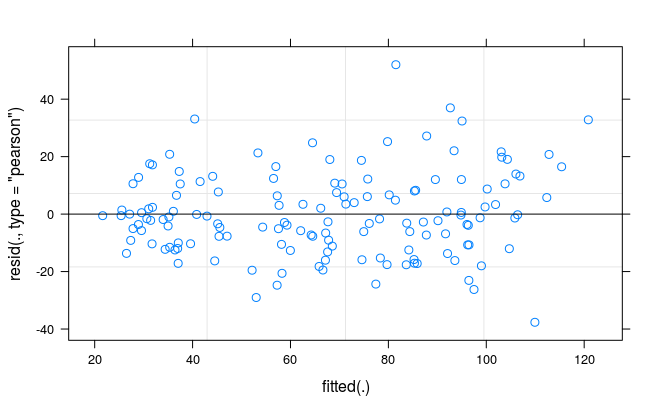

```r
  plot(m2) %>% print
```

```r
  DF = GetFstat(m2)
  DFmain = left_join(DFmain, DF)
```

## R3 biomass and N uptake

```r
m1 = lmer(T3_kgdw_ha~ R_Year.c*Fert + (1|Rep) + (1|Pos) + (1|Pos:Fert) + (1|Genotype) + (1|Rep:Row:Pos),  data = Data, na.action = na.exclude)
  anova(m1, ddf = "Kenward-Roger")
```

```
Analysis of Variance Table of type III  with  Kenward-Roger
approximation for degrees of freedom
                Sum Sq  Mean Sq NumDF  DenDF F.value   Pr(>F)
R_Year.c      21171201 21171201     1  3.794  9.0325  0.04251 *
Fert          77967568 38983784     2 17.663 16.6321 8.68e-05 ***
R_Year.c:Fert  8640565  4320282     2 39.784  1.8432  0.17157
---
Signif. codes:  0 ‘***’ 0.001 ‘**’ 0.01 ‘*’ 0.05 ‘.’ 0.1 ‘ ’ 1
```

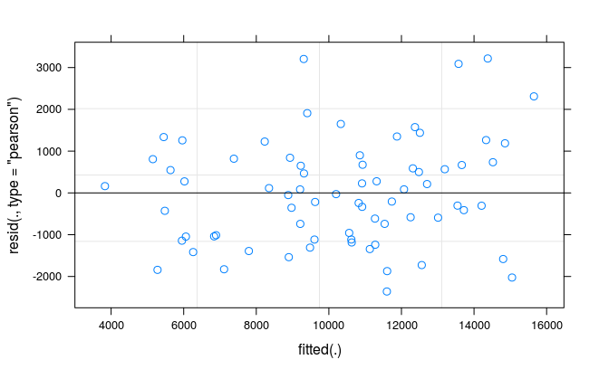

```r
  plot(m1) %>% print
```

```r
  DF = GetFstat(m1)
  DFsup = left_join(DFsup, DF)
m2 = lmer(T3_kgN_ha~ R_Year.c*Fert + (1|Rep)   + (1|Pos) + (1|Pos:Fert) + (1|Genotype) + (1|Rep:Row:Pos),  data = Data, na.action = na.exclude)
  anova(m2, ddf = "Kenward-Roger")
```

```
Analysis of Variance Table of type III  with  Kenward-Roger
approximation for degrees of freedom
              Sum Sq Mean Sq NumDF  DenDF F.value Pr(>F)
R_Year.c      3.5911  3.5911     1  3.884 1.85091 0.2473
Fert          9.1424  4.5712     2 22.279 2.35606 0.1180
R_Year.c:Fert 0.5672  0.2836     2 39.461 0.14617 0.8645
```

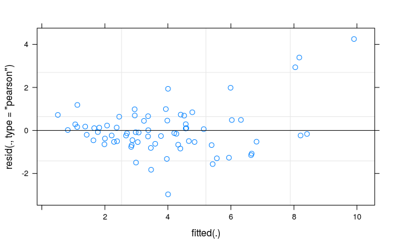

```r
  plot(m2) %>% print
```

```r
  DF = GetFstat(m2)
  DFsup = left_join(DFsup, DF)
```

# Partitioning N from soil and fertilizer

N uptake from soil in fertilized plots calculated as:

Sample_FracN_fromSoil = (Sample_X15N_AtPercent - At%label) / (T2_average_at%_in_control - At%label)

Sample_kgSoilN_ha = Sample_FracN_fromSoil x sample_FracN x Sample_kgdw_ha

where fertilizer was mized to 1 Atom % 15N

## Models

### N uptake from soil:

```r
sub = Data %>%
  filter(!is.na(Grain_FracN_fromSoil)) %>%
  mutate(TotalSoilN = ifelse(Fert == 0, Final_kgN_ha, Total_kgSoilN_ha),
         T2_SoilN = ifelse(Fert == 0,T2_kgN_ha, T2_kgSoilN_ha))
m = lmer(T2_SoilN ~  R_Year.c*Fert + (1|Rep) + (1|Pos) + (1|Pos:Fert) + (1|Genotype) + (1|Rep:Row:Pos),  data = sub, na.action = na.exclude)
  m@call %>% print
```

```
lme4::lmer(formula = T2_SoilN ~ R_Year.c * Fert + (1 | Rep) +
    (1 | Pos) + (1 | Pos:Fert) + (1 | Genotype) + (1 | Rep:Row:Pos),
    data = sub, na.action = na.exclude)
```

```r
  anova(m, ddf = "Kenward-Roger")
```

```
Analysis of Variance Table of type III  with  Kenward-Roger
approximation for degrees of freedom
              Sum Sq Mean Sq NumDF  DenDF F.value Pr(>F)
R_Year.c      621.49  621.49     1  3.898  4.0603 0.1160
Fert           65.95   32.97     2 30.788  0.2154 0.8074
R_Year.c:Fert  34.15   17.08     2 41.161  0.1116 0.8947
```

```r
  summary(m) %>% print
```

```
Linear mixed model fit by REML t-tests use Satterthwaite approximations to degrees of
  freedom [lmerMod]
Formula: T2_SoilN ~ R_Year.c * Fert + (1 | Rep) + (1 | Pos) + (1 | Pos:Fert) +
    (1 | Genotype) + (1 | Rep:Row:Pos)
   Data: sub

REML criterion at convergence: 555.2

Scaled residuals:
    Min      1Q  Median      3Q     Max
-1.3129 -0.6513 -0.1332  0.4651  4.2293

Random effects:
 Groups      Name        Variance Std.Dev.
 Rep:Row:Pos (Intercept)   0.000   0.000
 Pos:Fert    (Intercept)   0.000   0.000
 Genotype    (Intercept)   8.445   2.906
 Pos         (Intercept)   0.000   0.000
 Rep         (Intercept)  17.943   4.236
 Residual                153.066  12.372
Number of obs: 71, groups:  Rep:Row:Pos, 24; Pos:Fert, 12; Genotype, 6; Pos, 4; Rep, 4

Fixed effects:
                 Estimate Std. Error       df t value Pr(>|t|)
(Intercept)      32.59716    5.77264 17.88000   5.647  2.4e-05 ***
R_Year.c          0.11598    0.11054 17.36000   1.049    0.308
Fert85            3.64070    6.87014 57.92000   0.530    0.598
Fert170          -0.62090    6.87014 57.92000  -0.090    0.928
R_Year.c:Fert85   0.06612    0.14140 57.92000   0.468    0.642
R_Year.c:Fert170  0.04714    0.14140 57.92000   0.333    0.740
---
Signif. codes:  0 ‘***’ 0.001 ‘**’ 0.01 ‘*’ 0.05 ‘.’ 0.1 ‘ ’ 1

Correlation of Fixed Effects:
            (Intr) R_Yr.c Fert85 Frt170 R_Y.:F8
R_Year.c    -0.789
Fert85      -0.596  0.543
Fert170     -0.596  0.543  0.501
R_Yr.c:Fr85  0.505 -0.641 -0.851 -0.424
R_Yr.c:F170  0.505 -0.641 -0.424 -0.851  0.501
```

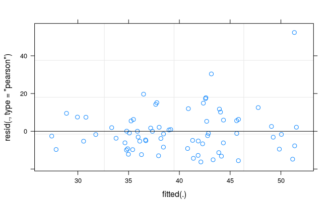

```r
  plot(m) %>% print
```

```r
  DF = GetFstat(m)
  DFmain = left_join(DFmain, DF)
m1 = lmer(TotalSoilN ~  R_Year.c*Fert + (1|Rep) + (1|Pos) + (1|Pos:Fert) + (1|Genotype) + (1|Rep:Row:Pos),  data = sub, na.action = na.exclude)
  m1@call %>% print
```

```
lme4::lmer(formula = TotalSoilN ~ R_Year.c * Fert + (1 | Rep) +
    (1 | Pos) + (1 | Pos:Fert) + (1 | Genotype) + (1 | Rep:Row:Pos),
    data = sub, na.action = na.exclude)
```

```r
  anova(m1, ddf = "Kenward-Roger")
```

```
Analysis of Variance Table of type III  with  Kenward-Roger
approximation for degrees of freedom
               Sum Sq Mean Sq NumDF  DenDF F.value  Pr(>F)
R_Year.c      1108.71 1108.71     1  3.949 11.0943 0.02966 *
Fert           286.85  143.42     2 30.729  1.4352 0.25359
R_Year.c:Fert   90.45   45.22     2 41.110  0.4525 0.63914
---
Signif. codes:  0 ‘***’ 0.001 ‘**’ 0.01 ‘*’ 0.05 ‘.’ 0.1 ‘ ’ 1
```

```r
  summary(m1) %>% print
```

```
Linear mixed model fit by REML t-tests use Satterthwaite approximations to degrees of
  freedom [lmerMod]
Formula: TotalSoilN ~ R_Year.c * Fert + (1 | Rep) + (1 | Pos) + (1 | Pos:Fert) +
    (1 | Genotype) + (1 | Rep:Row:Pos)
   Data: sub

REML criterion at convergence: 539.1

Scaled residuals:
     Min       1Q   Median       3Q      Max
-1.61703 -0.66844 -0.03269  0.50673  2.79877

Random effects:
 Groups      Name        Variance Std.Dev.
 Rep:Row:Pos (Intercept) 15.10    3.887
 Pos:Fert    (Intercept)  0.00    0.000
 Genotype    (Intercept) 18.65    4.318
 Pos         (Intercept)  0.00    0.000
 Rep         (Intercept) 36.56    6.047
 Residual                99.93    9.997
Number of obs: 71, groups:  Rep:Row:Pos, 24; Pos:Fert, 12; Genotype, 6; Pos, 4; Rep, 4

Fixed effects:
                 Estimate Std. Error       df t value Pr(>|t|)
(Intercept)      37.79914    6.19572 10.87000   6.101 8.14e-05 ***
R_Year.c          0.29477    0.11131  9.16000   2.648   0.0262 *
Fert85            0.10674    5.55171 42.79000   0.019   0.9848
Fert170           8.37176    5.55171 42.79000   1.508   0.1389
R_Year.c:Fert85   0.06814    0.11427 42.80000   0.596   0.5541
R_Year.c:Fert170 -0.04144    0.11427 42.80000  -0.363   0.7187
---
Signif. codes:  0 ‘***’ 0.001 ‘**’ 0.01 ‘*’ 0.05 ‘.’ 0.1 ‘ ’ 1

Correlation of Fixed Effects:
            (Intr) R_Yr.c Fert85 Frt170 R_Y.:F8
R_Year.c    -0.742
Fert85      -0.449  0.435
Fert170     -0.449  0.435  0.501
R_Yr.c:Fr85  0.380 -0.514 -0.850 -0.424
R_Yr.c:F170  0.380 -0.514 -0.424 -0.850  0.501
```

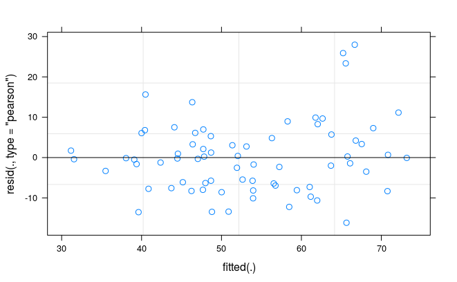

```r
  plot(m1) %>% print
```

```r
  r.squaredGLMM(m1)
```

```
      R2m       R2c
0.2901262 0.5833154
```

```r
  DF = GetFstat(m1)
  DFmain = left_join(DFmain, DF)
```

### N uptake from fertilizer:

```r
sub = Data %>% filter(Fert != 0 & !is.na(Total_kgFertN_ha))
dim(sub)
```

```
[1] 48 88
```

```r
m1 = lmer(T2_kgFertN_ha ~  R_Year.c*Fert + (1|Rep) + (1|Pos) +  (1|Pos:Fert) + (1|Genotype) + (1|Rep:Row:Pos),  data = sub, na.action = na.exclude)
  anova(m1, ddf = "Kenward-Roger")
```

```
Analysis of Variance Table of type III  with  Kenward-Roger
approximation for degrees of freedom
              Sum Sq Mean Sq NumDF   DenDF F.value    Pr(>F)
R_Year.c        58.7    58.7     1  3.9751   1.051    0.3636
Fert          3175.1  3175.1     1 15.7696  56.826 1.301e-06 ***
R_Year.c:Fert   21.0    21.0     1 21.0065   0.377    0.5461
---
Signif. codes:  0 ‘***’ 0.001 ‘**’ 0.01 ‘*’ 0.05 ‘.’ 0.1 ‘ ’ 1
```

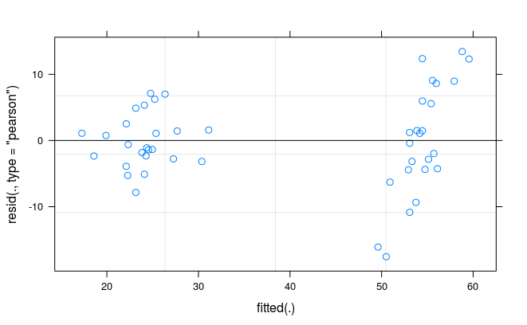

```r
 #summary(m1) %>% print
  plot(m1, title = "Final_kgN_ha") %>% print
```

```r
  DF = GetFstat(m1)
  DFmain = left_join(DFmain, DF)
m1 = lmer(log(Total_kgFertN_ha) ~  R_Year.c*Fert + (1|Rep) + (1|Pos) + (1|Pos:Fert) + (1|Genotype) + (1|Rep:Row:Pos),  data = sub, na.action = na.exclude)
  anova(m1, ddf = "Kenward-Roger")
```

```
Analysis of Variance Table of type III  with  Kenward-Roger
approximation for degrees of freedom
               Sum Sq Mean Sq NumDF   DenDF F.value    Pr(>F)
R_Year.c      0.26619 0.26619     1  3.9859   5.910   0.07212 .
Fert          2.95341 2.95341     1 15.7696  65.576 5.238e-07 ***
R_Year.c:Fert 0.02511 0.02511     1 21.0065   0.557   0.46356
---
Signif. codes:  0 ‘***’ 0.001 ‘**’ 0.01 ‘*’ 0.05 ‘.’ 0.1 ‘ ’ 1
```

```r
 summary(m1) %>% print
```

```
Linear mixed model fit by REML t-tests use Satterthwaite approximations to degrees of
  freedom [lmerMod]
Formula: log(Total_kgFertN_ha) ~ R_Year.c * Fert + (1 | Rep) + (1 | Pos) +
    (1 | Pos:Fert) + (1 | Genotype) + (1 | Rep:Row:Pos)
   Data: sub

REML criterion at convergence: 25

Scaled residuals:
     Min       1Q   Median       3Q      Max
-2.25742 -0.61146  0.00927  0.70965  1.66962

Random effects:
 Groups      Name        Variance Std.Dev.
 Rep:Row:Pos (Intercept) 0.007208 0.08490
 Pos:Fert    (Intercept) 0.000000 0.00000
 Genotype    (Intercept) 0.007318 0.08554
 Pos         (Intercept) 0.000000 0.00000
 Rep         (Intercept) 0.004966 0.07047
 Residual                0.045038 0.21222
Number of obs: 48, groups:  Rep:Row:Pos, 24; Pos:Fert, 8; Genotype, 6; Pos, 4; Rep, 4

Fixed effects:
                  Estimate Std. Error        df t value Pr(>|t|)
(Intercept)       2.909388   0.117427  8.155000  24.776 5.76e-09 ***
R_Year.c          0.005808   0.002305  7.439000   2.519   0.0379 *
Fert170           0.993038   0.117749 22.000000   8.434 2.43e-08 ***
R_Year.c:Fert170 -0.001875   0.002423 22.000000  -0.774   0.4473
---
Signif. codes:  0 ‘***’ 0.001 ‘**’ 0.01 ‘*’ 0.05 ‘.’ 0.1 ‘ ’ 1

Correlation of Fixed Effects:
            (Intr) R_Yr.c Frt170
R_Year.c    -0.815
Fert170     -0.501  0.449
R_Yr.c:F170  0.428 -0.526 -0.854
```

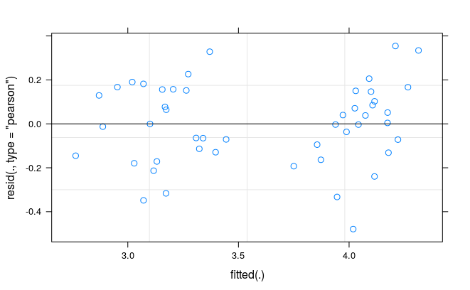

```r
  plot(m1, title = "Final_kgN_ha") %>% print
```

```r
  DF = GetFstat(m1)
  DFmain = left_join(DFmain, DF)
m1 = lmer(log(Total_kgFertN_ha) ~  R_Year.c*Fert + (1|Rep) + (1|Pos) + (1|Pos:Fert) + (1|Genotype) + (1|Rep:Row:Pos),  data = sub, na.action = na.exclude)
  anova(m1, ddf = "Kenward-Roger")
```

```
Analysis of Variance Table of type III  with  Kenward-Roger
approximation for degrees of freedom
               Sum Sq Mean Sq NumDF   DenDF F.value    Pr(>F)
R_Year.c      0.26619 0.26619     1  3.9859   5.910   0.07212 .
Fert          2.95341 2.95341     1 15.7696  65.576 5.238e-07 ***
R_Year.c:Fert 0.02511 0.02511     1 21.0065   0.557   0.46356
---
Signif. codes:  0 ‘***’ 0.001 ‘**’ 0.01 ‘*’ 0.05 ‘.’ 0.1 ‘ ’ 1
```

```r
 summary(m1) %>% print
```

```
Linear mixed model fit by REML t-tests use Satterthwaite approximations to degrees of
  freedom [lmerMod]
Formula: log(Total_kgFertN_ha) ~ R_Year.c * Fert + (1 | Rep) + (1 | Pos) +
    (1 | Pos:Fert) + (1 | Genotype) + (1 | Rep:Row:Pos)
   Data: sub

REML criterion at convergence: 25

Scaled residuals:
     Min       1Q   Median       3Q      Max
-2.25742 -0.61146  0.00927  0.70965  1.66962

Random effects:
 Groups      Name        Variance Std.Dev.
 Rep:Row:Pos (Intercept) 0.007208 0.08490
 Pos:Fert    (Intercept) 0.000000 0.00000
 Genotype    (Intercept) 0.007318 0.08554
 Pos         (Intercept) 0.000000 0.00000
 Rep         (Intercept) 0.004966 0.07047
 Residual                0.045038 0.21222
Number of obs: 48, groups:  Rep:Row:Pos, 24; Pos:Fert, 8; Genotype, 6; Pos, 4; Rep, 4

Fixed effects:
                  Estimate Std. Error        df t value Pr(>|t|)
(Intercept)       2.909388   0.117427  8.155000  24.776 5.76e-09 ***
R_Year.c          0.005808   0.002305  7.439000   2.519   0.0379 *
Fert170           0.993038   0.117749 22.000000   8.434 2.43e-08 ***
R_Year.c:Fert170 -0.001875   0.002423 22.000000  -0.774   0.4473
---
Signif. codes:  0 ‘***’ 0.001 ‘**’ 0.01 ‘*’ 0.05 ‘.’ 0.1 ‘ ’ 1

Correlation of Fixed Effects:
            (Intr) R_Yr.c Frt170
R_Year.c    -0.815
Fert170     -0.501  0.449
R_Yr.c:F170  0.428 -0.526 -0.854
```

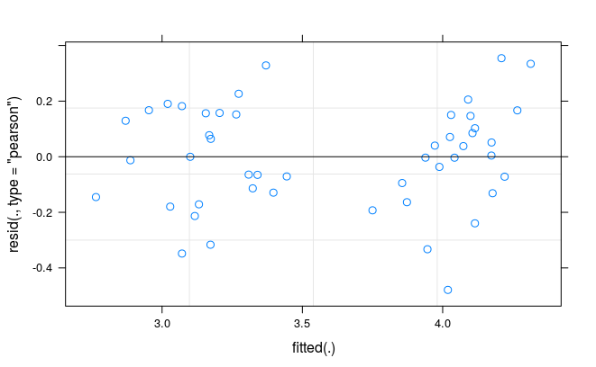

```r
  plot(m1, title = "Final_kgN_ha") %>% print
```

```r
sub85 = Data %>% filter(Fert == 85 & !is.na(Total_kgFertN_ha))
m1 = lmer(Total_kgFertN_ha ~  R_Year.c + (1|Rep) + (1|Pos) + (1|Genotype),  data = sub85, na.action = na.exclude)
  anova(m1, ddf = "Kenward-Roger")
```

```
Analysis of Variance Table of type III  with  Kenward-Roger
approximation for degrees of freedom
         Sum Sq Mean Sq NumDF  DenDF F.value  Pr(>F)
R_Year.c 276.67  276.67     1 3.9589  10.711 0.03118 *
---
Signif. codes:  0 ‘***’ 0.001 ‘**’ 0.01 ‘*’ 0.05 ‘.’ 0.1 ‘ ’ 1
```

```r
 summary(m1) %>% print
```

```
Linear mixed model fit by REML t-tests use Satterthwaite approximations to degrees of
  freedom [lmerMod]
Formula: Total_kgFertN_ha ~ R_Year.c + (1 | Rep) + (1 | Pos) + (1 | Genotype)
   Data: sub85

REML criterion at convergence: 146.8

Scaled residuals:
    Min      1Q  Median      3Q     Max
-1.9502 -0.6493 -0.2143  0.5019  2.2634

Random effects:
 Groups   Name        Variance  Std.Dev.
 Genotype (Intercept) 0.000e+00 0.000e+00
 Pos      (Intercept) 5.700e-16 2.387e-08
 Rep      (Intercept) 0.000e+00 0.000e+00
 Residual             2.583e+01 5.082e+00
Number of obs: 24, groups:  Genotype, 6; Pos, 4; Rep, 4

Fixed effects:
            Estimate Std. Error       df t value Pr(>|t|)
(Intercept) 18.31224    1.99393 22.00000   9.184 5.55e-09 ***
R_Year.c     0.13917    0.04103 22.00000   3.392  0.00262 **
---
Signif. codes:  0 ‘***’ 0.001 ‘**’ 0.01 ‘*’ 0.05 ‘.’ 0.1 ‘ ’ 1

Correlation of Fixed Effects:
         (Intr)
R_Year.c -0.854
```

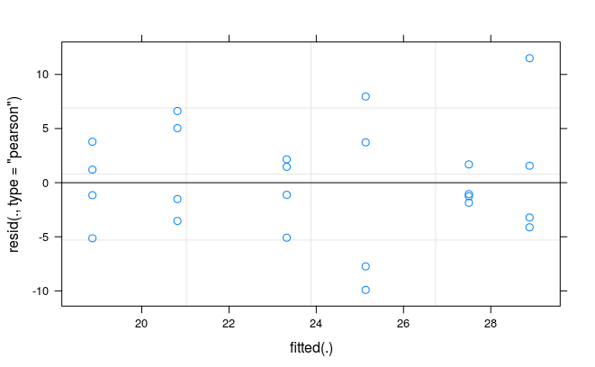

```r
  plot(m1) %>% print
```

```r
  r.squaredGLMM(m1)
```

```
      R2m       R2c
0.3334266 0.3334266
```

```r
sub170 = Data %>% filter(Fert == 170 & !is.na(Total_kgFertN_ha))
  m1 = lmer(Total_kgFertN_ha ~  R_Year.c + (1|Rep) + (1|Pos) + (1|Genotype),  data = sub170, na.action = na.exclude)
  anova(m1, ddf = "Kenward-Roger")
```

```
Analysis of Variance Table of type III  with  Kenward-Roger
approximation for degrees of freedom
         Sum Sq Mean Sq NumDF  DenDF F.value Pr(>F)
R_Year.c 144.74  144.74     1 3.9985  1.1853 0.3375
```

```r
 summary(m1) %>% print
```

```
Linear mixed model fit by REML t-tests use Satterthwaite approximations to degrees of
  freedom [lmerMod]
Formula: Total_kgFertN_ha ~ R_Year.c + (1 | Rep) + (1 | Pos) + (1 | Genotype)
   Data: sub170

REML criterion at convergence: 191.8

Scaled residuals:
     Min       1Q   Median       3Q      Max
-1.92008 -0.41240  0.03242  0.52492  1.62162

Random effects:
 Groups   Name        Variance Std.Dev.
 Genotype (Intercept) 170.60   13.061
 Pos      (Intercept)   0.00    0.000
 Rep      (Intercept)  41.31    6.427
 Residual             122.11   11.050
Number of obs: 24, groups:  Genotype, 6; Pos, 4; Rep, 4

Fixed effects:
            Estimate Std. Error      df t value Pr(>|t|)
(Intercept)  50.2544    11.5827  4.5980   4.339    0.009 **
R_Year.c      0.2511     0.2290  4.0000   1.097    0.334
---
Signif. codes:  0 ‘***’ 0.001 ‘**’ 0.01 ‘*’ 0.05 ‘.’ 0.1 ‘ ’ 1

Correlation of Fixed Effects:
         (Intr)
R_Year.c -0.820
```

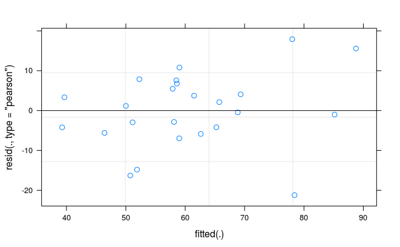

```r
  plot(m1) %>% print
```

```r
  r.squaredGLMM(m1)
```

```
      R2m       R2c
0.1118745 0.6753247
```

## Plot uptake from soil and fertilizer at PM

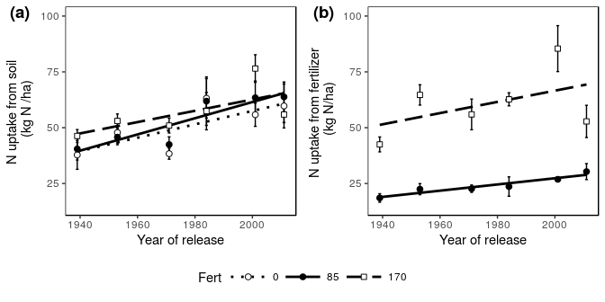

# Does timing of growth and N uptake change?

## Post anthesis N uptake

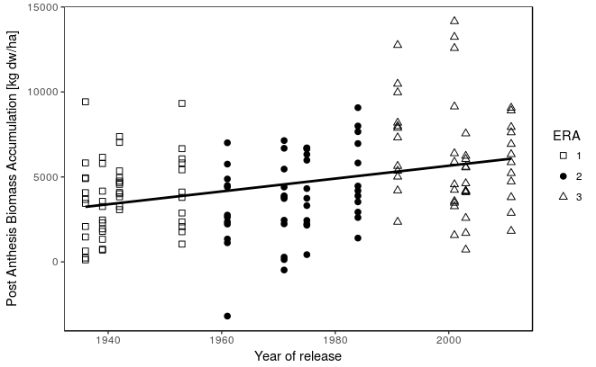

- Post anthesis biomass accumulation was greater for modern hybrids:

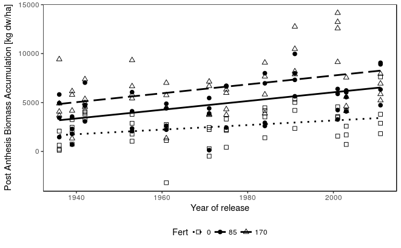

```r
m1 = lmer(PostAnthesis_kgdw_ha  ~  R_Year.c*Fert + (1|Rep)+ (1|Pos:Fert) + (1|Genotype) + (1|Rep:Row:Pos),  data = Data, na.action = na.exclude)
  anova(m1, ddf = "Kenward-Roger")
```

```
Analysis of Variance Table of type III  with  Kenward-Roger
approximation for degrees of freedom
                Sum Sq  Mean Sq NumDF  DenDF F.value    Pr(>F)
R_Year.c      32642591 32642591     1 10.000  8.8062 0.0141060 *
Fert          72708848 36354424     2 38.744  9.8076 0.0003578 ***
R_Year.c:Fert  9129048  4564524     2 91.903  1.2314 0.2966539
---
Signif. codes:  0 ‘***’ 0.001 ‘**’ 0.01 ‘*’ 0.05 ‘.’ 0.1 ‘ ’ 1
```

```r
  summary(m1) %>% print
```

```
Linear mixed model fit by REML t-tests use Satterthwaite approximations to degrees of
  freedom [lmerMod]
Formula: PostAnthesis_kgdw_ha ~ R_Year.c * Fert + (1 | Rep) + (1 | Pos:Fert) +
    (1 | Genotype) + (1 | Rep:Row:Pos)
   Data: Data

REML criterion at convergence: 2535.7

Scaled residuals:
    Min      1Q  Median      3Q     Max
-2.3579 -0.6634 -0.0157  0.6222  2.8729

Random effects:
 Groups      Name        Variance Std.Dev.
 Rep:Row:Pos (Intercept)       0     0.0
 Genotype    (Intercept)  914004   956.0
 Pos:Fert    (Intercept)       0     0.0
 Rep         (Intercept)   15947   126.3
 Residual                3706777  1925.3
Number of obs: 144, groups:  Rep:Row:Pos, 48; Genotype, 12; Pos:Fert, 12; Rep, 4

Fixed effects:
                 Estimate Std. Error      df t value Pr(>|t|)
(Intercept)       1646.05     702.32   21.86   2.344   0.0286 *
R_Year.c            23.39      15.56   21.87   1.504   0.1470
Fert85            1503.20     701.88   71.28   2.142   0.0356 *
Fert170           3163.67     701.88   71.28   4.507 2.51e-05 ***
R_Year.c:Fert85     21.17      15.61   71.28   1.356   0.1793
R_Year.c:Fert170    22.02      15.61   71.28   1.410   0.1628
---
Signif. codes:  0 ‘***’ 0.001 ‘**’ 0.01 ‘*’ 0.05 ‘.’ 0.1 ‘ ’ 1

Correlation of Fixed Effects:
            (Intr) R_Yr.c Fert85 Frt170 R_Y.:F8
R_Year.c    -0.825
Fert85      -0.500  0.416
Fert170     -0.500  0.416  0.500
R_Yr.c:Fr85  0.414 -0.502 -0.829 -0.414
R_Yr.c:F170  0.414 -0.502 -0.414 -0.829  0.500
```

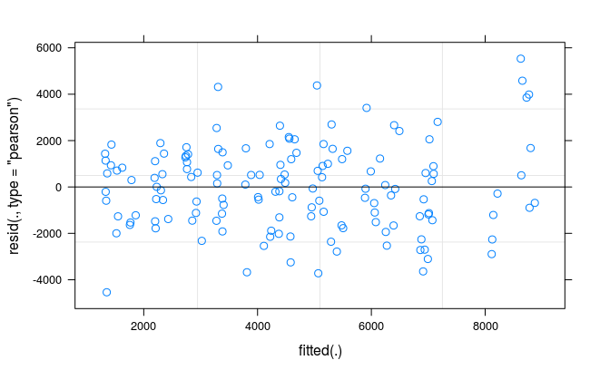

```r
  plot(m1) %>% print
```

```r
  DF = GetFstat(m1)
  DFmain = left_join(DFmain, DF)
```

# Plots for supplementary info

*Nute, percent grain N R1 Nuptake, post anthesis N uptake biomass and N partitioning total stover N, total grain N

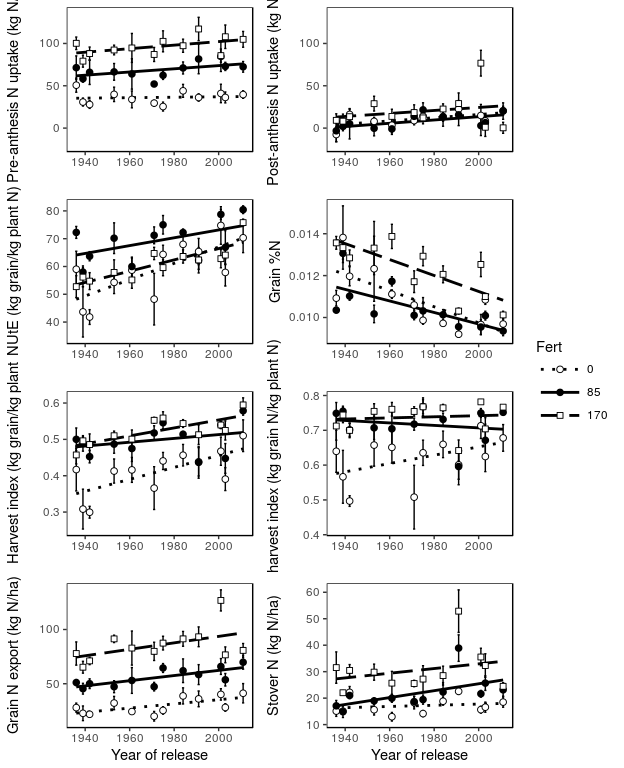

```r
svg(filename = '/home/bryan/ERA/data/figures/ms_versions/NUE_supplemental.svg', width = 6.5, height = 7.5)
grid.arrange(RightRow, Fertlegend2, ncol = 2, widths = c(1,.2))
dev.off()
```

```r
m2 = lmer(PostAnthesis_kgN_ha  ~  R_Year.c*Fert + (1|Rep) + (1|Pos) + (1|Pos:Fert) + (1|Genotype) + (1|Rep:Row:Pos),  data = Data, na.action = na.exclude)
  anova(m2, ddf = "Kenward-Roger")
```

```
Analysis of Variance Table of type III  with  Kenward-Roger
approximation for degrees of freedom
               Sum Sq Mean Sq NumDF  DenDF F.value  Pr(>F)
R_Year.c      1804.47 1804.47     1  9.914  4.5759 0.05835 .
Fert          1099.22  549.61     2 30.987  1.3937 0.26327
R_Year.c:Fert    3.99    1.99     2 90.975  0.0051 0.99495
---
Signif. codes:  0 ‘***’ 0.001 ‘**’ 0.01 ‘*’ 0.05 ‘.’ 0.1 ‘ ’ 1
```

```r
 summary(m2)
```

```
Linear mixed model fit by REML t-tests use Satterthwaite approximations to degrees of
  freedom [lmerMod]
Formula: PostAnthesis_kgN_ha ~ R_Year.c * Fert + (1 | Rep) + (1 | Pos) +
    (1 | Pos:Fert) + (1 | Genotype) + (1 | Rep:Row:Pos)
   Data: Data

REML criterion at convergence: 1255.1

Scaled residuals:
    Min      1Q  Median      3Q     Max
-2.0975 -0.6587  0.0636  0.5050  3.5197

Random effects:
 Groups      Name        Variance Std.Dev.
 Rep:Row:Pos (Intercept)   0.00    0.00
 Genotype    (Intercept)  21.07    4.59
 Pos:Fert    (Intercept)   0.00    0.00
 Pos         (Intercept)   0.00    0.00
 Rep         (Intercept)   0.00    0.00
 Residual                394.34   19.86
Number of obs: 143, groups:
Rep:Row:Pos, 48; Genotype, 12; Pos:Fert, 12; Pos, 4; Rep, 4

Fixed effects:
                   Estimate Std. Error         df t value Pr(>|t|)
(Intercept)        3.731547   5.639556  43.880000   0.662    0.512
R_Year.c           0.189293   0.125440  43.880000   1.509    0.138
Fert85            -2.728461   7.273830 127.160000  -0.375    0.708
Fert170            9.145659   7.239413 127.050000   1.263    0.209
R_Year.c:Fert85    0.003432   0.161202 127.070000   0.021    0.983
R_Year.c:Fert170  -0.012370   0.161025 127.050000  -0.077    0.939

Correlation of Fixed Effects:
            (Intr) R_Yr.c Fert85 Frt170 R_Y.:F8
R_Year.c    -0.829
Fert85      -0.639  0.529
Fert170     -0.642  0.532  0.498
R_Yr.c:Fr85  0.531 -0.641 -0.828 -0.414
R_Yr.c:F170  0.532 -0.642 -0.412 -0.829  0.499
```

```r
  DF = GetFstat(m2)
  DFmain = left_join(DFmain, DF)
```

# Compare fertilizer recovery by 15N and difference

- Calculate fertilizer recovery effeincy by 15N and difference method
- Recover efficiency 15N method: Total_kgFertN_ha / FertApplied
- Apparent recovery efficiency by difference RE = Final_kgN_ha - Final_kgN_ha at 0kgN) / Fert

```r
tmp = Data %>%
    select(PlotID, Rep, Row, Pos, Genotype,R_Year, R_Year.c, Fert, Final_kgN_ha, T2_d15N, Total_kgFertN_ha) %>%
    mutate(FertilizerN = as.numeric(as.character(Fert))) %>%
    group_by(Rep, Row, Pos) %>%
    mutate(FertN_difference = (Final_kgN_ha - Final_kgN_ha[Fert == "0"])) %>%
    ungroup() %>%
    filter(Fert != "0") # & !is.na(T2_d15N))
head(tmp)
```

| PlotID | Rep | Row | Pos | Genotype | R_Year | R_Year.c | Fert | Final_kgN_ha | T2_d15N | Total_kgFertN_ha | FertilizerN | FertN_difference |
| --- | --- | --- | --- | --- | --- | --- | --- | --- | --- | --- | --- | --- |
| 1-3a_85 | 1 | 3 | a | 1936 | 1936 | 1 | 85 | 63.94270 | NA | NA | 85 | 31.02023 |
| 1-3a_170 | 1 | 3 | a | 1936 | 1936 | 1 | 170 | 95.75574 | NA | NA | 170 | 62.83327 |
| 2-5b_170 | 2 | 5 | b | 1936 | 1936 | 1 | 170 | 152.07580 | NA | NA | 170 | 104.20501 |
| 2-5b_85 | 2 | 5 | b | 1936 | 1936 | 1 | 85 | 67.93753 | NA | NA | 85 | 20.06674 |
| 3-4a_85 | 3 | 4 | a | 1936 | 1936 | 1 | 85 | 73.36122 | NA | NA | 85 | 27.29850 |
| 3-4a_170 | 3 | 4 | a | 1936 | 1936 | 1 | 170 | 90.02380 | NA | NA | 170 | 43.96108 |

```r
m2 = lmer(FertN_difference  ~  R_Year.c*Fert + (1|Rep) + (1|Pos) + (1|Pos:Fert) + (1|Genotype) + (1|Rep:Row:Pos),  data = tmp, na.action = na.exclude)
  anova(m2, ddf = "Kenward-Roger")
```

```
Analysis of Variance Table of type III  with  Kenward-Roger
approximation for degrees of freedom
              Sum Sq Mean Sq NumDF  DenDF F.value    Pr(>F)
R_Year.c       671.3   671.3     1  9.898   2.180    0.1709
Fert          9752.3  9752.3     1 15.188  31.675 4.588e-05 ***
R_Year.c:Fert    2.4     2.4     1 45.136   0.008    0.9299
---
Signif. codes:  0 ‘***’ 0.001 ‘**’ 0.01 ‘*’ 0.05 ‘.’ 0.1 ‘ ’ 1
```

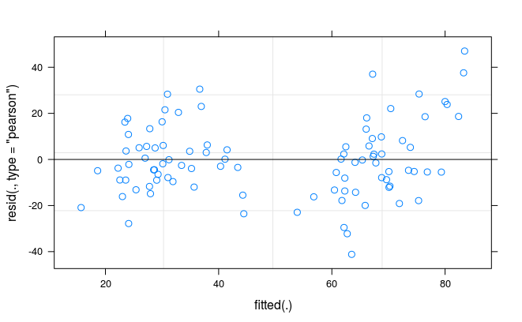

```r
  #summary(m2) %>% print
 plot(m2, title = "Final_kgN_ha") %>% print
```

```r
 DF = GetFstat(m2)
 DFmain = left_join(DFmain, DF)
 tmp = tmp %>% filter(!is.na(Total_kgFertN_ha)) %>%
             mutate(FertN_difference_subset = FertN_difference)
 m2 = lmer(FertN_difference_subset  ~  R_Year.c*Fert + (1|Rep) + (1|Pos) + (1|Pos:Fert) + (1|Genotype) + (1|Rep:Row:Pos),  data = tmp, na.action = na.exclude)
  anova(m2, ddf = "Kenward-Roger")
```

```
Analysis of Variance Table of type III  with  Kenward-Roger
approximation for degrees of freedom
              Sum Sq Mean Sq NumDF   DenDF F.value   Pr(>F)
R_Year.c       317.7   317.7     1  3.9676  0.8998 0.396963
Fert          4787.1  4787.1     1 15.0105 13.5593 0.002216 **
R_Year.c:Fert    0.1     0.1     1 20.8603  0.0002 0.988729
---
Signif. codes:  0 ‘***’ 0.001 ‘**’ 0.01 ‘*’ 0.05 ‘.’ 0.1 ‘ ’ 1
```

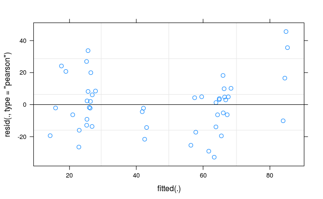

```r
  #summary(m2) %>% print
 plot(m2, title = "Final_kgN_ha") %>% print
```

```r
 DF = GetFstat(m2)
 DFmain = left_join(DFmain, DF)
```

## compare apparent RE with 15n based RE

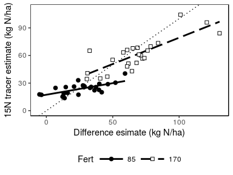

```r
pComp = ggplot(tmp, aes(x = FertN_difference, y = Total_kgFertN_ha, shape = Fert)) +
  geom_smooth(aes(linetype = Fert), method = "lm", se = FALSE, color = "black") +
   scale_shape_manual(values = c(21,22))+
  geom_point(aes(fill = Fert), size = 2) +
    theme_pub() +
   xlab("Difference esimate (kg N/ha)")+
  ylab("15N tracer estimate (kg N/ha)") +
   #xlim(c(0,110))+
  ylim(c(0,110))+
  scale_fill_manual(values = c("black", "white")) +
    geom_abline(intercept = 0, linetype = 3) +
    scale_linetype_manual(values = c(1,5))+
  theme(legend.position = "bottom", legend.key.width = unit(2.5,"line"))
pComp
```

```r
svg(filename = '/home/bryan/ERA/data/figures/ms_versions/TracerVsDif.svg', width = 3.14, height = 3.5)
pComp %>% print
dev.off()
```

# Output of F-tests

```r
t(DFmain) %>% as.data.frame()
```

|  | V1 | V2 | V3 |
| --- | --- | --- | --- |
| Factors | R_Year.c | Fert | R_Year.c:Fert |
| Grain_kgdw_ha | F( 1 , 10.02 ) = 22.95 *** | F( 2 , 28.02 ) = 52.54 *** | F( 2 , 91.93 ) = 3.05 . |
| Final_kgN_ha | F( 1 , 9.96 ) = 9.51 * | F( 2 , 30.84 ) = 61.85 *** | F( 2 , 90.88 ) = 1.13 |
| T2_kgdw_ha | F( 1 , 10.12 ) = 4.77 . | F( 2 , 15.34 ) = 11.5 *** | F( 2 , 89.42 ) = 0.11 |
| T2_kgN_ha | F( 1 , 9.98 ) = 3.38 . | F( 2 , 31.89 ) = 39.54 *** | F( 2 , 91.87 ) = 1.12 |
| T2_SoilN | F( 1 , 3.9 ) = 4.06 | F( 2 , 30.79 ) = 0.22 | F( 2 , 41.16 ) = 0.11 |
| TotalSoilN | F( 1 , 3.95 ) = 11.09 * | F( 2 , 30.73 ) = 1.44 | F( 2 , 41.11 ) = 0.45 |
| T2_kgFertN_ha | F( 1 , 3.98 ) = 1.05 | F( 1 , 15.77 ) = 56.83 *** | F( 1 , 21.01 ) = 0.38 |
| Total_kgFertN_ha | F( 1 , 3.99 ) = 5.91 . | F( 1 , 15.77 ) = 65.58 *** | F( 1 , 21.01 ) = 0.56 |
| PostAnthesis_kgdw_ha | F( 1 , 10 ) = 8.81 * | F( 2 , 38.74 ) = 9.81 *** | F( 2 , 91.9 ) = 1.23 |

[output cut: 3 more lines]

```r
t(DFsup) %>% as.data.frame()
```

|  | V1 | V2 | V3 |
| --- | --- | --- | --- |
| Factors | R_Year.c | Fert | R_Year.c:Fert |
| NUtE | F( 1 , 9.95 ) = 19.8 ** | F( 2 , 30.94 ) = 15.28 *** | F( 2 , 90.94 ) = 2.75 . |
| Grain_kgN_ha | F( 1 , 9.96 ) = 9.11 * | F( 2 , 30.83 ) = 69.73 *** | F( 2 , 90.88 ) = 0.58 |
| Grain_FracN.leco | F( 1 , 10.05 ) = 27.62 *** | F( 2 , 27.74 ) = 15.02 *** | F( 2 , 91.12 ) = 0.9 |
| Stover_kgN_ha | F( 1 , 10 ) = 2.09 | F( 2 , 31.89 ) = 12.89 *** | F( 2 , 91.87 ) = 2.98 . |
| Stover_FracN.leco | F( 1 , 10.07 ) = 0.08 | F( 2 , 31.89 ) = 8.3 ** | F( 2 , 91.87 ) = 1.8 |
| HarvestIndexBiomass | F( 1 , 10 ) = 9.3 * | F( 2 , 31.89 ) = 36.3 *** | F( 2 , 91.87 ) = 3.98 * |
| HarvestIndexN | F( 1 , 9.99 ) = 0.42 | F( 2 , 30.9 ) = 30.93 *** | F( 2 , 90.92 ) = 4.86 ** |
| T1_kgdw_ha | F( 1 , 10.13 ) = 1.18 | F( 2 , 10.73 ) = 1.43 | F( 2 , 86.94 ) = 0.11 |
| T1_kgN_ha | F( 1 , 10.2 ) = 2.46 | F( 2 , 9.33 ) = 3.15 . | F( 2 , 85.54 ) = 0.21 |

[output cut: 2 more lines]

# Does seed treatment effect growth or N uptake

## T2

Biomass:

```
Analysis of Variance Table of type III  with  Kenward-Roger
approximation for degrees of freedom
                        Sum Sq Mean Sq NumDF DenDF F.value Pr(>F)
Genotype               1351466  450489     3    21 0.30905 0.8186
SeedTreatment          3335945 3335945     1    21 2.28855 0.1452
Genotype:SeedTreatment  690922  230307     3    21 0.15800 0.9233
```

- Genotype and GenotypeXSeedtreatment are not significant at T2 and removed from model
- At T2 there is no difference in biomass accumulation, if anything a slight increase in biomass accumulation without seed treatment

N uptake:

```r
m1 = lmer(T2_kgN_ha ~  Genotype*SeedTreatment + (1|Rep),  data = sub, na.action = na.exclude)
  anova(m1, ddf = "Kenward-Roger")
```

```
Analysis of Variance Table of type III  with  Kenward-Roger
approximation for degrees of freedom
                       Sum Sq Mean Sq NumDF  DenDF F.value Pr(>F)
Genotype               196.44   65.48     3 20.076 0.16683 0.9175
SeedTreatment          394.51  394.51     1 20.083 1.00513 0.3280
Genotype:SeedTreatment 543.29  181.10     3 20.076 0.46140 0.7123
```

```r
  #summary(m1) %>% print
  #plot(m1) %>% print
```

- Nor is there a significant difference between the untreated and treated seeds in N uptake by T2, non-sigificant effects and interactions removed from the model

## Final yields

- Final N uptake

```r
m1 = lmer(Final_kgN_ha ~  Fert*SeedTreatment + Genotype*SeedTreatment + Fert:Genotype + (1|Rep) + (1|Pos) + (1|Pos:Fert) + (1|Rep:Pos:Row),  data = Data.sc, na.action = na.exclude)
  anova(m1, ddf = "Kenward-Roger")
```

```
Analysis of Variance Table of type III  with  Kenward-Roger
approximation for degrees of freedom
                        Sum Sq Mean Sq NumDF  DenDF F.value    Pr(>F)
Fert                   29442.0 14721.0     2  5.100  97.505 8.632e-05 ***
SeedTreatment             59.0    59.0     1 19.881   0.391    0.5391
Genotype                 747.4   249.1     3 19.836   1.650    0.2099
Fert:SeedTreatment        96.7    48.3     2 52.985   0.320    0.7274
SeedTreatment:Genotype   315.3   105.1     3 19.582   0.696    0.5655
Fert:Genotype            146.0    24.3     6 50.252   0.161    0.9858
---
Signif. codes:  0 ‘***’ 0.001 ‘**’ 0.01 ‘*’ 0.05 ‘.’ 0.1 ‘ ’ 1
```

```r
  #summary(m1) %>% print
  #plot(m1) %>% print
```

- Seed treatment does not affect N uptake at physiological maturity
- Both Genotype and GxS interaction were not significant, though residuals were funky in full model

Grain yield:

```r
m1 = lmer(Grain_kgdw_ha ~  Fert*SeedTreatment +  Genotype*SeedTreatment + Fert:Genotype
          + (1|Rep) + (1|Pos) + (1|Pos:Fert)+ (1|Rep:Pos:Row),  data = Data.sc, na.action = na.exclude)
  anova(m1, ddf = "Kenward-Roger")
```

```
Analysis of Variance Table of type III  with  Kenward-Roger
approximation for degrees of freedom
                          Sum Sq   Mean Sq NumDF  DenDF F.value    Pr(>F)
Fert                   206956287 103478143     2  4.414 169.138 6.741e-05 ***
SeedTreatment             286496    286496     1 17.172   0.468  0.502909
Genotype                 9355530   3118510     3 20.045   5.097  0.008769 **
Fert:SeedTreatment         66863     33432     2 45.005   0.055  0.946884
SeedTreatment:Genotype   1652893    550964     3 19.881   0.901  0.458373
Fert:Genotype            4962630    827105     6 52.313   1.352  0.251417
---
Signif. codes:  0 ‘***’ 0.001 ‘**’ 0.01 ‘*’ 0.05 ‘.’ 0.1 ‘ ’ 1
```

```r
  # summary(m1) %>% print
  # plot(m1) %>% print
```

- No effect of seed treatment on final yield

## Plot seed treatment:

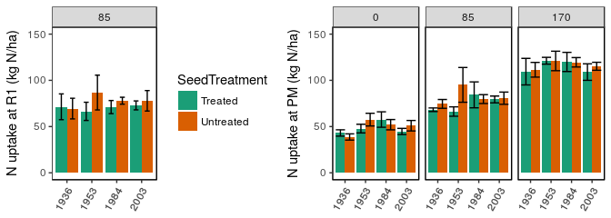

```r
svg(filename = '/home/bryan/ERA/data/figures/ms_versions/SeedTreatment_growth.svg', width = 6.5, height = 3.15)
grid.arrange(p1, p3, ncol = 2, widths = c(.84,1))
dev.off()
```

- No effect of seed treatment on plant growth and N uptake